# Homework #5

Zechen Wang (zew20@pitt.edu)

April 8, 2019

```r
setwd("D:/workspace/r/INFSCI 2160 Data Mining/Week05")

library(tm)
library(lsa)
library(ggplot2)
library(recommenderlab)
```

## Task 1 (Text Mining): Analyze the topical clusters from text data. We will use the Reuters newsgroup dataset available on Piazza. The dataset description can be found here: https://www.cs.umb.edu/~smimarog/textmining/datasets/

### 1. Plot the histogram of number of documents per topic. Find and list the four most popular topics in terms of number of documents.

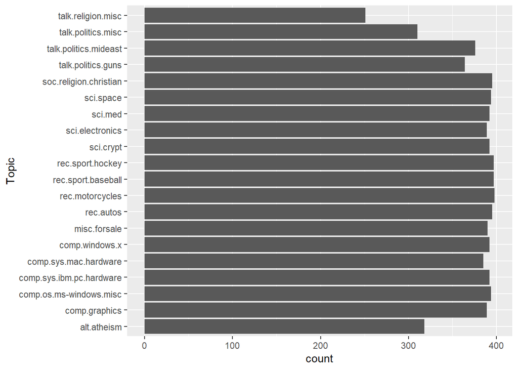

```r
newsgroup <- read.csv('HOMEWORK_5_REUTERS_NEWSGROUP.csv', header = T, sep = ',')
newsgroup <- newsgroup[newsgroup$Topic!="",]
ggplot(newsgroup, aes(x=Topic)) + geom_bar() + coord_flip()
```

#### the four most popular topics are:

```r
newsgroup.tbl <- summary(newsgroup$Topic)
top.topics <- t(data.frame(sort(newsgroup.tbl, decreasing = T)))
rownames(top.topics) <- 'freq'
top4.topics <- colnames(top.topics)[1:4]
top4.topics
```

```
## [1] "rec.motorcycles"    "rec.sport.baseball" "rec.sport.hockey"
## [4] "rec.autos"
```

### 2. Extract contents in these top 4 topics as your corpus. Run pre-processing on this corpus and use terms that appear at least 4 times in the corpus to create a term-document matrix. Use the term-document matrix to generate an MDS plot (reviewed in class) where each node represents a document with color indicating its topic.

```r
df <- newsgroup[newsgroup$Topic %in% top4.topics,]
df$Topic <- as.character(df$Topic)
df$Content <- as.character(df$Content)
dim(df)
```

```
## [1] 1587    2
```

```r
corpus <- Corpus(VectorSource(df$Content))
corpus <- tm_map(corpus, tolower)
tm::inspect(corpus[1:3])
```

```
## <<SimpleCorpus>>
## Metadata:  corpus specific: 1, document level (indexed): 0
## Content:  documents: 3
##
## [1] auto air condit freon articl hvx new cso uiuc edu tspila uxa cso uiuc edu tim spila romulan write articl apr ntuix ntu mgqlu ntuix ntu max write work ga solid adsorpt air con system for auto applic thi kind system energi for regener adsorb exhaust ga interest thi mail email follow thi thread …
## [2] auto air condit freon rovax tobia convex allen tobia write year ago demonstr cold air system us air call rovax unit work short come seal technolog todai recal read post back rovax rovac di larger and noisier compet cheap system dai case bad time system chanc todai that system death row invest…
## [3] auto air condit freon simpl principl porou adsorb zeolit and activ carbon can adsorb gase evapor adsorb water methanol etc give cool effect heat ga satur adsorb bed will give gase condens thi form adsorpt refriger cycl problem that cop low max max phd internet mgqlu ntu divis thermal engin bi…
```

```r
corpus <- tm_map(corpus, removePunctuation)
corpus <- tm_map(corpus, removeNumbers)
corpus <- tm_map(corpus, function(x) removeWords(x, stopwords("english")))
corpus <- tm_map(corpus, stemDocument, language = "english")
corpus = tm_map(corpus, stripWhitespace)
tm::inspect(corpus[1:3])
```

```
## <<SimpleCorpus>>
## Metadata:  corpus specific: 1, document level (indexed): 0
## Content:  documents: 3
##
## [1] auto air condit freon articl hvx new cso uiuc edu tspila uxa cso uiuc edu tim spila romulan write articl apr ntuix ntu mgqlu ntuix ntu max write work ga solid adsorpt air con system auto applic thi kind system energi regen adsorb exhaust ga interest thi mail email follow thi thread discuss pr…
## [2] auto air condit freon rovax tobia convex allen tobia write year ago demonstr cold air system us air call rovax unit work short come seal technolog todai recal read post back rovax rovac di larger noisier compet cheap system dai case bad time system chanc todai system death row investor hard c…
## [3] auto air condit freon simpl principl porou adsorb zeolit activ carbon can adsorb gase evapor adsorb water methanol etc give cool effect heat ga satur adsorb bed will give gase conden thi form adsorpt refrig cycl problem cop low max max phd internet mgqlu ntu divi thermal engin bitnet mgqlu nt…
```

```r
dtm <- TermDocumentMatrix(corpus)
tm::inspect(dtm)
```

```
## <<TermDocumentMatrix (terms: 13547, documents: 1587)>>
## Non-/sparse entries: 107445/21391644
## Sparsity           : 100%
## Maximal term length: 79
## Weighting          : term frequency (tf)
## Sample             :
##         Docs
## Terms    1059 1138 1373 1374 1387 1389 1466 160 166 217
##   articl    0    3    0    0    0    0    0   1   0   0
##   can      10    8    1    0    0    1    4   1  13   2
##   car       0    0    0    0    0    0    0  30  42  20
##   don       0    5    0    0    0    0    0   1  10   0
##   edu       0    4    0    0    0    1    0   4   1   0
##   game      5    0    0    0    0   12    5   0   0   0
##   thi      15   12    3    0    0    1    3  12  32  10
##   will      1    8    0    0    0    0    0   1   0   6
##   write     1    3    0    0    0    0    0   3   1   0
##   year      0   11    2    0    0    0    1   1   1   0
```

```r
td.mat <- as.matrix(dtm)
dim(td.mat)
```

```
## [1] 13547  1587
```

#### use terms that appear at least 4 times in the corpus

```r
td.mat <- td.mat[rownames(td.mat) %in% findFreqTerms(dtm, 4),]
dim(td.mat)
```

```
## [1] 5313 1587
```

```r
dist.mat <- dist(t(as.matrix(td.mat))) ## compute distance matrix
```

#### generate mds plot

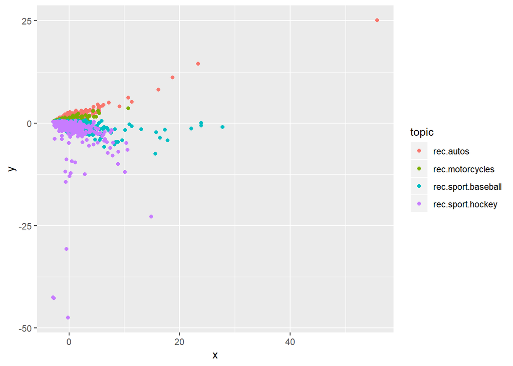

```r
doc.mds <- cmdscale(dist.mat, k = 2)
data <- data.frame(x = doc.mds[, 1], y = doc.mds[, 2], topic = df$Topic, id = row.names(df))
ggplot(data, aes(x = x, y = y, color=topic)) + geom_point()
```

### 3. Apply TDIDF weighting on the term document matrix. Next, apply latent semantic analysis on the term document matrix. Generate MDS plots corresponding to these matrices

#### tf-idf weighting and MDS Plot:

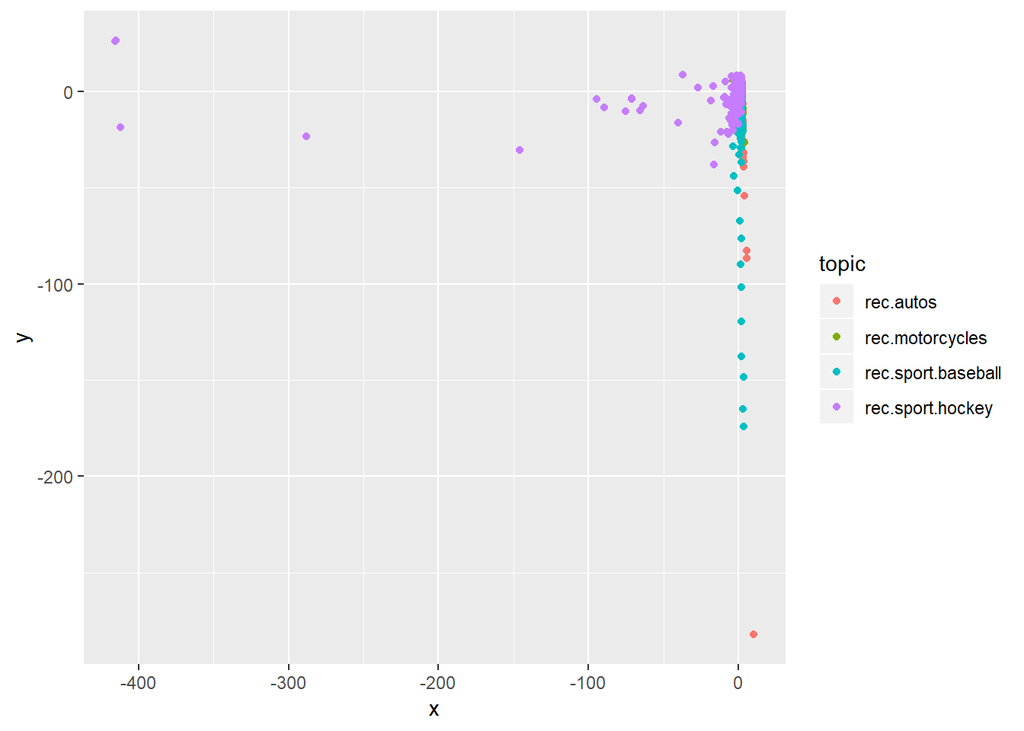

```r
td.mat = as.matrix(td.mat)
td.mat.w = lw_tf(td.mat) * gw_idf(td.mat)  ## tf-idf weighting
dist.mat = dist(t(as.matrix(td.mat.w))) ## compute distance matrix

# generate mds plot using new distance matrix
doc.mds <- cmdscale(dist.mat, k = 2)
data <- data.frame(x = doc.mds[, 1], y = doc.mds[, 2], topic = df$Topic, id = row.names(df))
ggplot(data, aes(x = x, y = y, color=topic)) + geom_point()
```

#### LSA and MDS Plot:

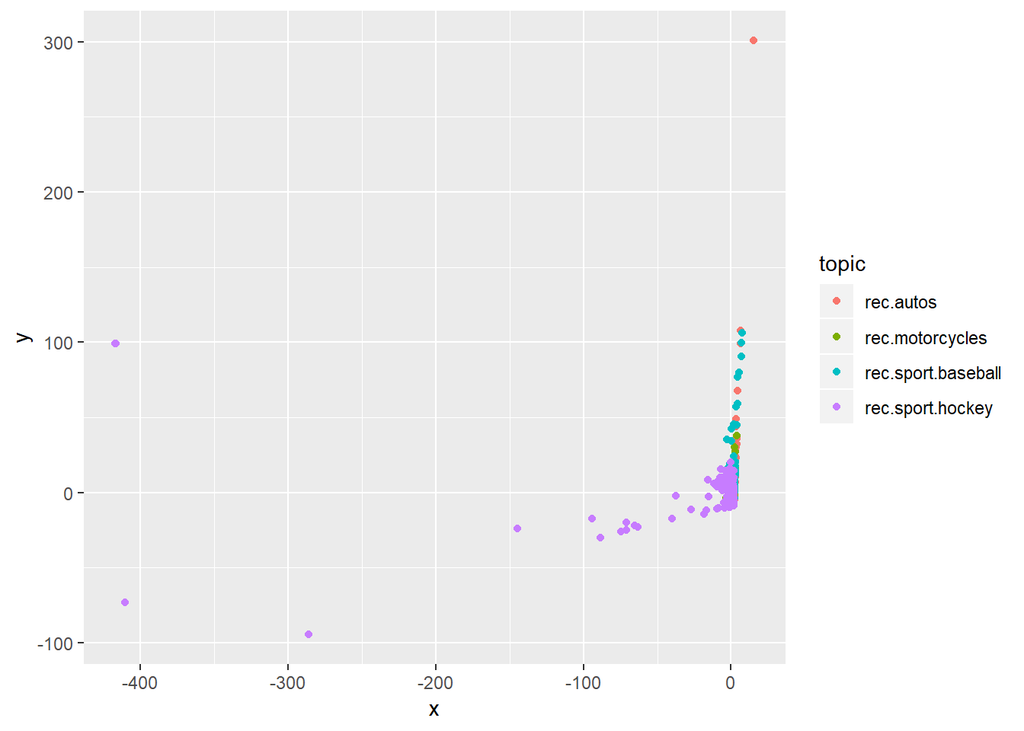

```r
lsa.space = lsa(td.mat.w, dims=3)  ## create LSA space
dist.mat = dist(t(as.textmatrix(lsa.space)))  ## compute distance matrix

doc.mds = cmdscale(dist.mat, k = 2)
data = data.frame(x = doc.mds[, 1], y = doc.mds[, 2], topic = df$Topic, id = row.names(df))
ggplot(data, aes(x = x, y = y, color=topic)) + geom_point()
```

### 4. Write down your observation based on these two plots.

#### **Answer:**

##### For the first MDS plot before doing the weighting, it shows that the four topics are slightly clustered together with some outliers.

##### After weighting, both MDS plots of tf-idf weighting and LSA indicate strong relationships between each topics due to the similarity of the association among words.

## Task 2 (Recommendation): create a recommender system based on the book rating data available here: http://www2.informatik.uni-freiburg.de/~cziegler/BX/. In the dataset, load the BX-Book-Ratings.csv and BX-Books.csv data. Extract books published from 1998 to present. Create a book rating matrix from these books, and in this matrix, only consider books that were rated by at least 10 users, and users that rated at least 10 books.

### 1. Run and test a recommender system built with different recommendation methods, including random, popular, user-based collaborative filtering, item-based collaborative filtering. Evaluate the different methods by using k-fold cross-validation (k = 4). Generate a performance table in terms of performance measures MAE, MSE, and RMSE. Hint: use “recommenderlab” library. Documentation can be found here: https://www.rdocumentation.org/packages/recommenderlab/versions/0.2-4

#### First of all, I did some data processing and cleaning by using some **java** codes (because it will lead to various problems when we read the original data set into Rstudio).

#### To process the “BX-Books.csv”:

```java
import java.io.*;

public class BooksHandle {
    public static void main(String[] args) {
        File file = new File("D:/workspace/r/INFSCI 2160 Data Mining/Week05/BX-Books - Copy.csv");
        BufferedReader reader;
        String outputName = "D:/workspace/r/INFSCI 2160 Data Mining/Week05/BX-Books - New.csv";
        BufferedWriter writer;
        try {
            File output = new File(outputName);
            if (!output.exists()) {
                File dir = new File(output.getParent());
                dir.mkdirs();
                output.createNewFile();
            }
            reader = new BufferedReader(new FileReader(file));
            writer = new BufferedWriter(new FileWriter(outputName));
            String line;
            while ((line = reader.readLine()) != null) {
                line = line.replace("\"", "'");
                line = line.replace("';'", "\";\"");
                line = line.replaceFirst("'", "\"");
                line = line.substring(0, line.length() - 1) + "\"";
                writer.write(line);
                writer.newLine();
            }
            writer.close();
            reader.close();
        } catch (IOException e) {
            e.printStackTrace();
        }
    }
}
```

#### To process the “BX-Book-Ratings.csv”:

```java
import java.io.*;

public class RatingsHandle {
    public static void main(String[] args) {
        File file = new File("D:/workspace/r/INFSCI 2160 Data Mining/Week05/BX-Book-Ratings - Copy.csv");
        BufferedReader reader;
        String outputName = "D:/workspace/r/INFSCI 2160 Data Mining/Week05/BX-Book-Ratings - New.csv";
        BufferedWriter writer;
        try {
            File output = new File(outputName);
            if (!output.exists()) {
                File dir = new File(output.getParent());
                dir.mkdirs();
                output.createNewFile();
            }
            reader = new BufferedReader(new FileReader(file));
            writer = new BufferedWriter(new FileWriter(outputName));
            String line;
            while ((line = reader.readLine()) != null) {
                line = line.replace("\"", "'");
                line = line.replace("';'", "\";\"");
                line = line.replaceFirst("'", "\"");
                line = line.substring(0, line.length() - 1) + "\"";
                line = line.replace("'", "");
                line = line.replace("\" ", "\"");
                line = line.replace("\"\\", "\"");
                line = line.replace("\\\"", "\"");
                line = line.replace("#", "");
                line = line.replace("(", "");
                line = line.replace(")", "");
                line = line.replace("+", "");
                line = line.replace("`", "");
                line = line.replace("=", "");
                line = line.replace("-", "");
                line = line.replace(" ", "");
                line = line.replace(".", "");
                line = line.replace("*", "");
                line = line.replace(",", "");
                line = line.replace("/", "");
                line = line.replace("_", "");
                line = line.replace(":", "");
                line = line.replace("@", "");
                writer.write(line);
                writer.newLine();
            }
            writer.close();
            reader.close();
        } catch (IOException e) {
            e.printStackTrace();
        }
    }
}
```

#### Extract books published from 1998 to present.

```r
ratings <- read.csv('BX-Book-Ratings - New.csv', header = T, sep = ';', stringsAsFactors = T)
books <- read.csv('BX-Books - New.csv', header = T, sep = ';', stringsAsFactors = T)

df <- books[books$Year.Of.Publication >= 1998, ]
summary(df$Year.Of.Publication)
```

```
##    Min. 1st Qu.  Median    Mean 3rd Qu.    Max.
##    1998    1999    2001    2001    2002    2050
```

```r
ratings.df <- ratings[ratings$ISBN %in% df$ISBN,]
```

#### Due to the data discription, “Ratings (‘Book-Rating’) are either explicit, expressed on a scale from 1-10 (higher values denoting higher appreciation), or implicit, expressed by 0.”, I filter the ratings which is 0 because they are implicit.

```r
ratings.df <- ratings.df[ratings.df$BookRating > 0,]
```

#### Only consider books that were rated by at least 10 users, and users that rated at least 10 books. I use a while-loop to implement this.

```r
len <- 0
while (len != nrow(ratings.df)) {
    len <- nrow(ratings.df)
    ratings.books <- data.frame(table(ratings.df$ISBN))
    ratings.books <- ratings.books[ratings.books$Freq > 0,]
    ratings.users <- data.frame(table(ratings.df$UserID))
    colnames(ratings.books) <- c('ISBN', 'Freq')
    val_books <- ratings.books[ratings.books$Freq >= 10, 'ISBN']
    ratings.df <- ratings.df[ratings.df$ISBN %in% val_books,]
    colnames(ratings.users) <- c('UserID', 'Freq')
    val_users <- ratings.users[ratings.users$Freq >= 10, 'UserID']
    ratings.df <- ratings.df[ratings.df$UserID %in% val_users,]
}

head(ratings.df, n = 12L)
```

```
##      UserID       ISBN BookRating
## 1466 277427 0060542128          7
## 1523 277427 0316776963          8
## 1544 277427 0345413903         10
## 1565 277427 0380702843          8
## 1584 277427 0385503857          9
## 1585 277427 0385504209          8
## 1648 277427 0440224764          7
## 1653 277427 0440236738          9
## 1671 277427 0446608890         10
## 1695 277427 0452284449          6
## 1800 277427 0743412028          9
## 9198 278633 0060987561         10
```

#### And check if they meet the condition “books that were rated by at least 10 users, and users that rated at least 10 books”.

```r
summary(data.frame(table(ratings.df$UserID))$Freq)
```

```
##    Min. 1st Qu.  Median    Mean 3rd Qu.    Max.
##   10.00   11.00   14.00   18.14   20.00  403.00
```

```r
summary(data.frame(table(ratings.df$ISBN))[data.frame(table(ratings.df$ISBN))$Freq>0, 'Freq'])
```

```
##    Min. 1st Qu.  Median    Mean 3rd Qu.    Max.
##   10.00   12.00   15.00   19.03   21.00  146.00
```

#### Then run and evaluate a recommender system built with different recommendation methods, including random, popular, user-based collaborative filtering, item-based collaborative filtering.

```r
r <- as(ratings.df, "realRatingMatrix")
r
```

```
## 731 x 697 rating matrix of class 'realRatingMatrix' with 13264 ratings.
```

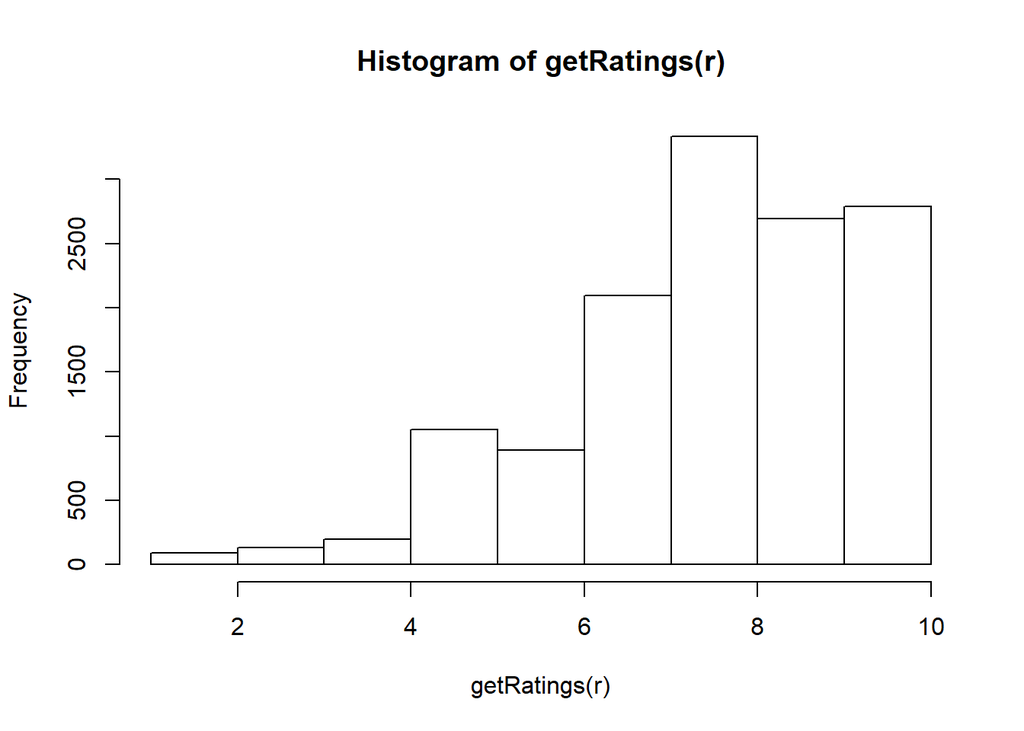

```r
hist(getRatings(r), breaks=10)
```

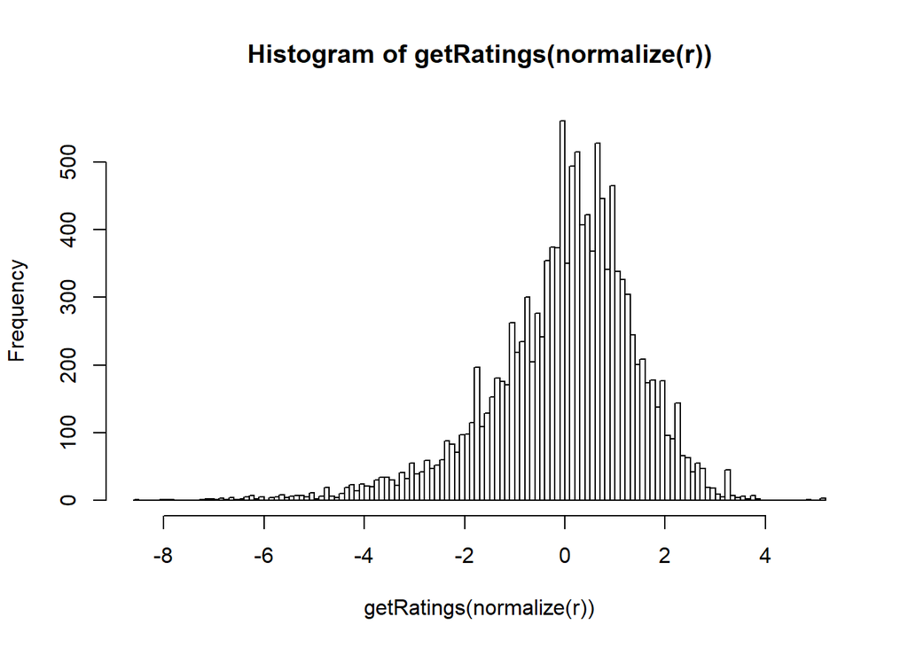

```r
hist(getRatings(normalize(r)), breaks=100)
```

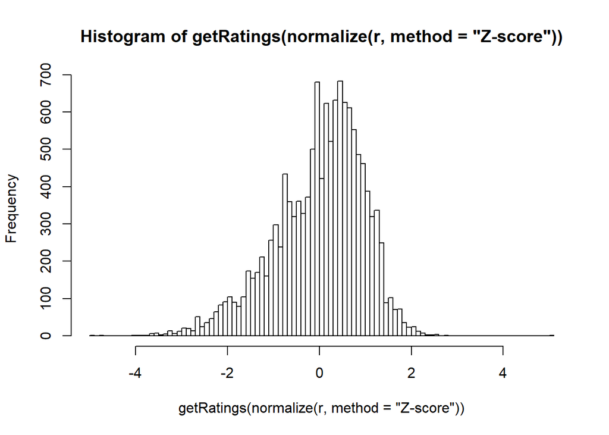

```r
hist(getRatings(normalize(r, method="Z-score")), breaks=100)
```

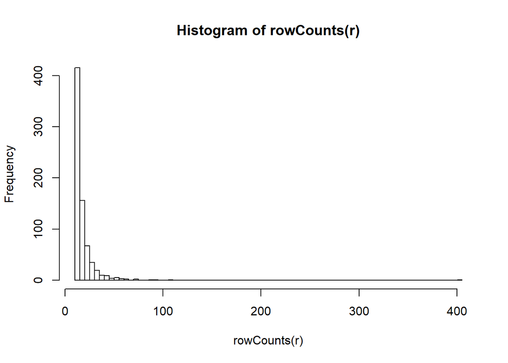

```r
hist(rowCounts(r), breaks=100)
```

```r
## comparison of several recommender algorithms
set.seed(12)
scheme <- evaluationScheme(r, method="cross-validation", k=4, given=-1, goodRating=10)
scheme
```

```
## Evaluation scheme using all-but-1 items
## Method: 'cross-validation' with 4 run(s).
## Good ratings: >=10.000000
## Data set: 731 x 697 rating matrix of class 'realRatingMatrix' with 13264 ratings.
```

```r
algorithms <- list(
    "random items" = list(name="RANDOM", param=NULL),
    "popular items" = list(name="POPULAR", param=NULL),
    "user-based CF" = list(name="UBCF", param=list(nn=50)),
    "item-based CF" = list(name="IBCF", param=list(k=50))
)


## run algorithms
results <- evaluate(scheme, algorithms, type = "topNList", n=c(1:20))
```

```
## RANDOM run fold/sample [model time/prediction time]
##   1  [0sec/0.1sec]
##   2  [0sec/0.08sec]
##   3  [0sec/0.06sec]
##   4  [0sec/0.06sec]
## POPULAR run fold/sample [model time/prediction time]
##   1  [0sec/0.32sec]
##   2  [0.02sec/0.29sec]
##   3  [0.02sec/0.23sec]
##   4  [0.02sec/0.33sec]
## UBCF run fold/sample [model time/prediction time]
##   1  [0sec/0.27sec]
##   2  [0sec/0.32sec]
##   3  [0sec/0.28sec]
##   4  [0sec/0.29sec]
## IBCF run fold/sample [model time/prediction time]
##   1  [1.72sec/0.05sec]
##   2  [1.67sec/0.06sec]
##   3  [2.19sec/0.05sec]
##   4  [1.6sec/0.06sec]
```

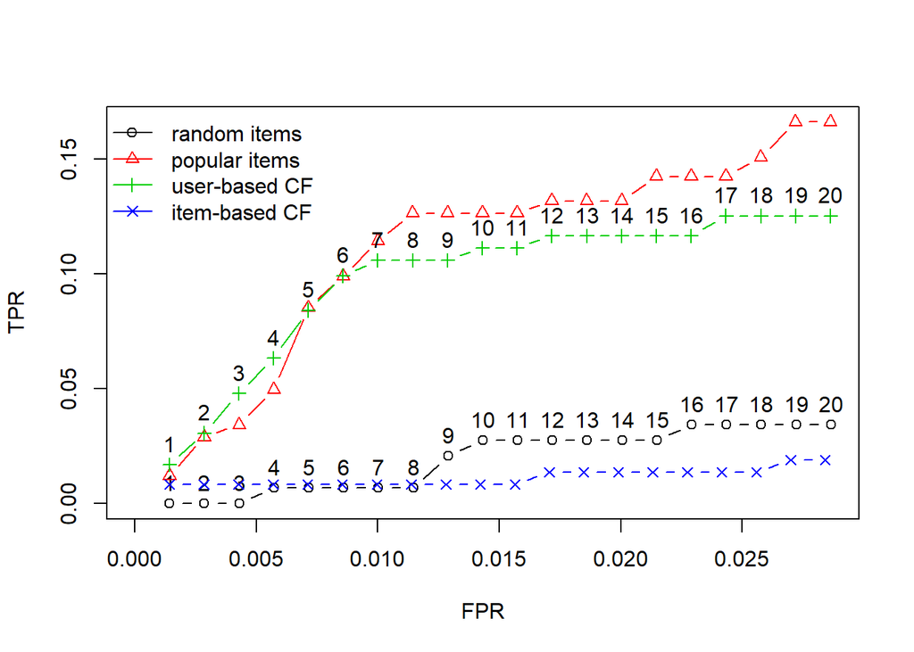

```r
plot(results, annotate=c(1, 3), legend="topleft")
```

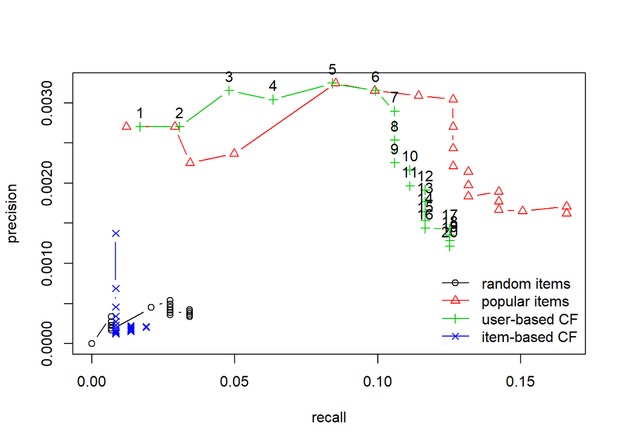

```r
plot(results, "prec/rec", annotate=3, legend="bottomright")
```

```r
## run algorithms
results <- evaluate(scheme, algorithms, type = "ratings")
```

```
## RANDOM run fold/sample [model time/prediction time]
##   1  [0sec/0.04sec]
##   2  [0sec/0.03sec]
##   3  [0sec/0.05sec]
##   4  [0sec/0.05sec]
## POPULAR run fold/sample [model time/prediction time]
##   1  [0sec/0.02sec]
##   2  [0.02sec/0sec]
##   3  [0sec/0.02sec]
##   4  [0sec/0.01sec]
## UBCF run fold/sample [model time/prediction time]
##   1  [0sec/0.25sec]
##   2  [0sec/0.32sec]
##   3  [0sec/0.27sec]
##   4  [0sec/0.34sec]
## IBCF run fold/sample [model time/prediction time]
##   1  [1.54sec/0.05sec]
##   2  [1.61sec/0.03sec]
##   3  [1.76sec/0.03sec]
##   4  [1.58sec/0.03sec]
```

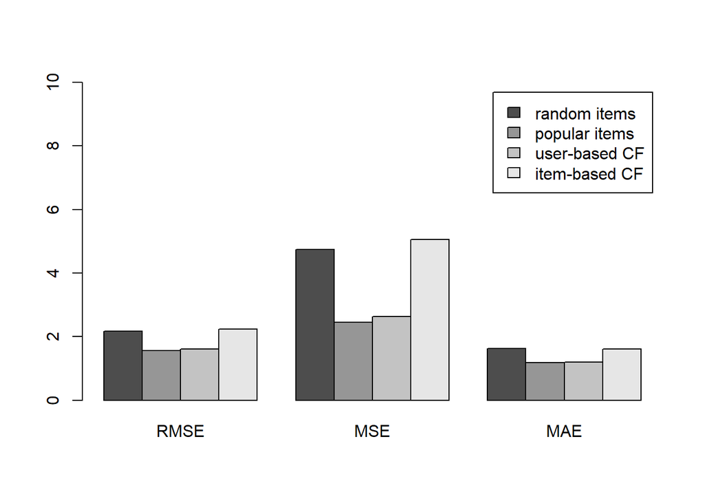

```r
plot(results, ylim = c(0, 10))
```

```r
avg(results)
```

```
## $`random items`
##         RMSE      MSE      MAE
## res 2.174645 4.740654 1.625325
##
## $`popular items`
##         RMSE      MSE      MAE
## res 1.559214 2.456375 1.180499
##
## $`user-based CF`
##         RMSE      MSE      MAE
## res 1.617019 2.629399 1.197261
##
## $`item-based CF`
##         RMSE      MSE      MAE
## res 2.242765 5.057442 1.606494
```

```r
tbl <- matrix(t(data.frame(avg(results)))[, "res"], nrow = 3, ncol = 4, byrow = F)
colnames(tbl) <- c('random items', 'popular items', 'user-based CF', 'item-based CF')
rownames(tbl) <- c('RMSE', 'MSE', 'MAE')
tbl
```

```
##      random items popular items user-based CF item-based CF
## RMSE     2.174645      1.559214      1.617019      2.242765
## MSE      4.740654      2.456375      2.629399      5.057442
## MAE      1.625325      1.180499      1.197261      1.606494
```

### 2. Write down your observations based on the final performance table.

#### **Answer:**

##### Popular and UBCF are more efficient than Random and IBCF for this dataset.

##### For the top 5 items, UBCF have a better performance than Popular, but the performance will reduce after the 6th item.

##### The TPR of IBCF does not increase until the 12th item, and in the precision/recall plot, the precision drops vertically before the 12th item.